# AETAS Kinderstiftung – Communicating a Violent Death to Children

Praxisprojekt – LMU Statistics and Data Science

Ben Ahmed Yassine , Ihidheb Ilyes , Nessah Nour, Tlili Eya

Marie scherzer

2025-12-18

# Welcome

Our goal is to understand how caregivers communicate a violent death to children and which forms of support are most needed.

# Agenda

- Overview
- Data Analysis
  - Stress & Experience of Caregivers
  - Communication with Children
  - Psychological Support
  - Stress & Coping
- Conclusion & Discussion

## Agenda

- Overview
- Data Analysis
  - Stress & Experience of Caregivers
  - Communication with Children
  - Psychological Support
  - Stress & Coping

- Conclusion & Discussion

# Overview

- *AETAS Kinderstiftung*: German foundation providing psychosocial support to children and families after trauma or death; source of the study data.

# Overview

- *AETAS Kinderstiftung*: German foundation providing psychosocial support to children and families after trauma or death; source of the study data.
- *Data* : Cross-sectional, retrospective self-reports with quantitative and qualitative responses.

# Overview

- *AETAS Kinderstiftung*: German foundation providing psychosocial support to children and families after trauma or death; source of the study data.
- *Data* : Cross-sectional, retrospective self-reports with quantitative and qualitative responses.
- *Data source*: Anonymized(2022) survey covering demographics, child communication, psychosocial support, information seeking, and wished-for support.

# Overview

- *AETAS Kinderstiftung*: German foundation providing psychosocial support to children and families after trauma or death; source of the study data.
- *Data* : Cross-sectional, retrospective self-reports with quantitative and qualitative responses.
- *Data source*: Anonymized(2022) survey covering demographics, child communication, psychosocial support, information seeking, and wished-for support.
- *Participants*: 64 parents and caregivers of children (0–17 years) after suicide or homicide of a close person.

# Overview

- *AETAS Kinderstiftung*: German foundation providing psychosocial support to children and families after trauma or death; source of the study data.
- *Data* : Cross-sectional, retrospective self-reports with quantitative and qualitative responses.
- *Data source*: Anonymized(2022) survey covering demographics, child communication, psychosocial support, information seeking, and wished-for support.
- *Participants*: 64 parents and caregivers of children (0–17 years) after suicide or homicide of a close person.
- *Goal*: Indentify helpful factors and unmet needs

## Agenda

- Overview

- Data Analysis
  - Stress & Experience of Caregivers
  - Communication with Children
  - Psychological Support
  - Stress & Coping

- Conclusion & Discussion

# Data Analysis

- Stress & Experience of Caregivers

- Communication with Children

- Psychological Support

- Stress & Coping

## Stress & Experience of Caregivers

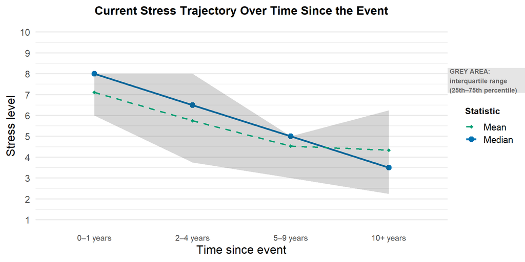

## Stress & Experience of Caregivers

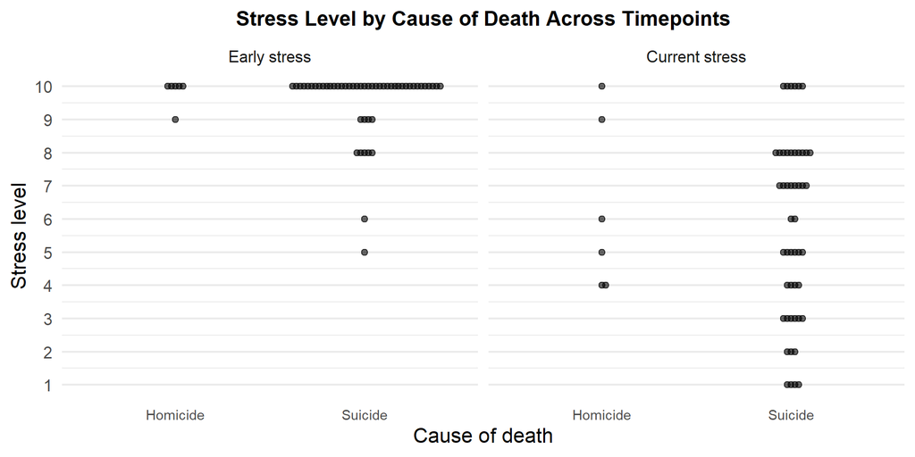

## Stress & Experience of Caregivers

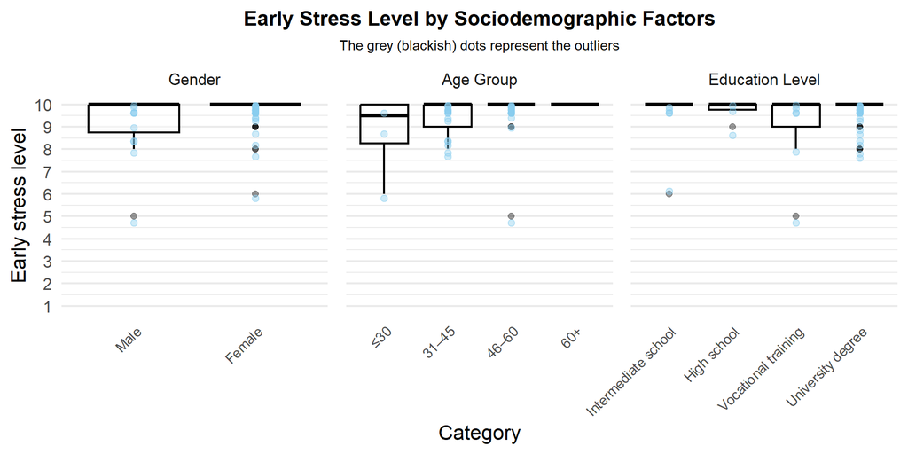

## Stress & Experience of Caregivers

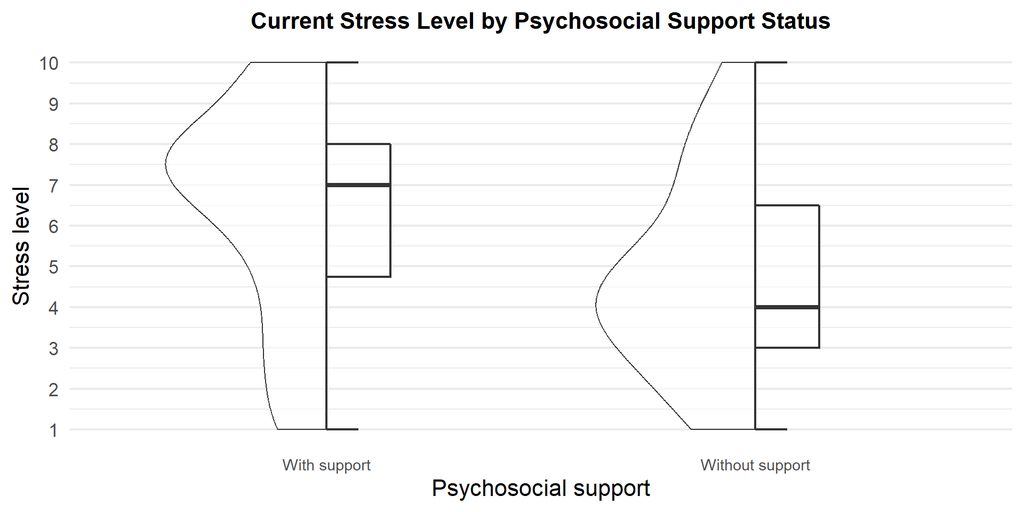

## Stress & Experience of Caregivers

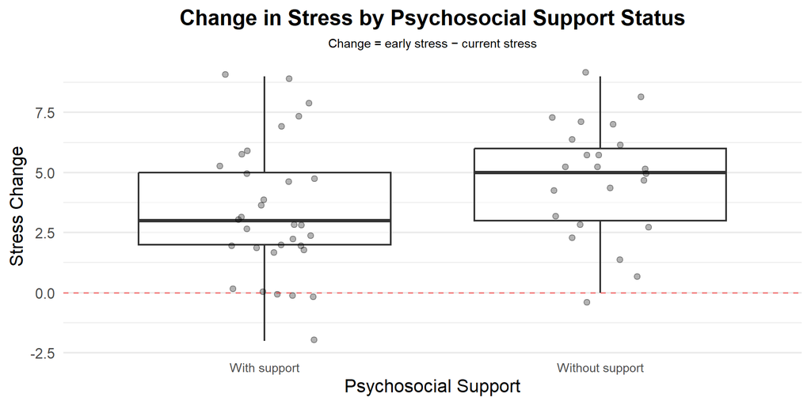

# Data Analysis

- Stress & Experience of Caregivers

- Communication with Children

- Psychological Support

- Stress & Coping

## Communication with Children

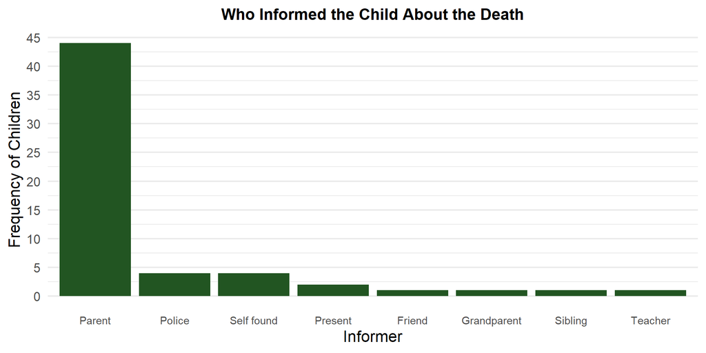

## Communication with Children

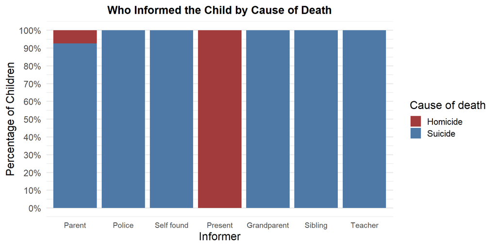

## Communication with Children

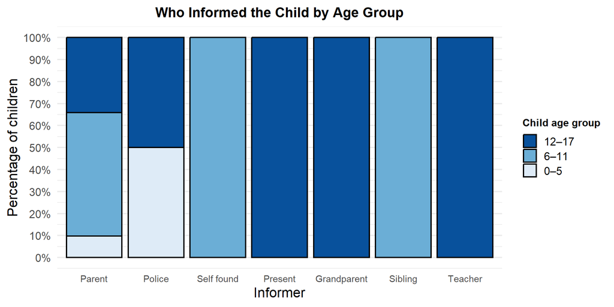

## Communication with Children

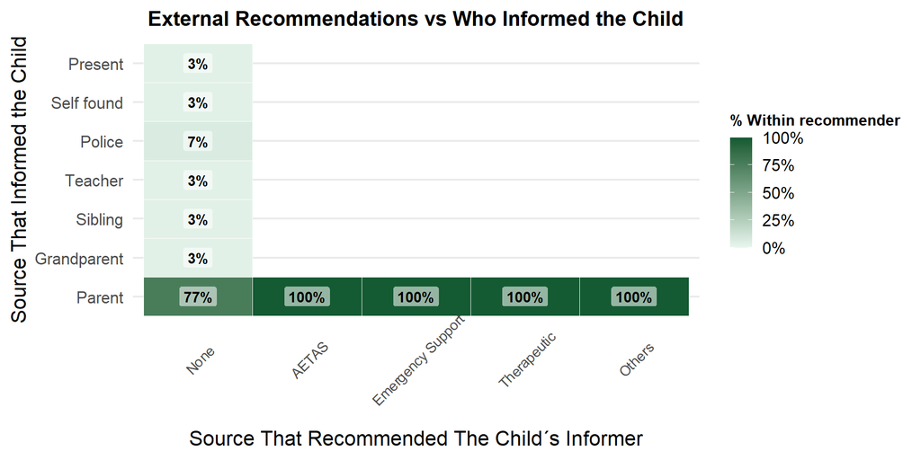

## Communication with Children

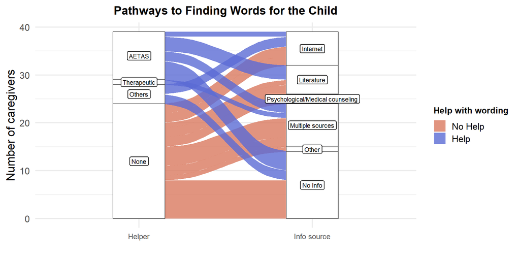

# Data Analysis

- Stress & Experience of Caregivers

- Communication with Children

- Psychological Support

- Stress & Coping

## Psychological Support

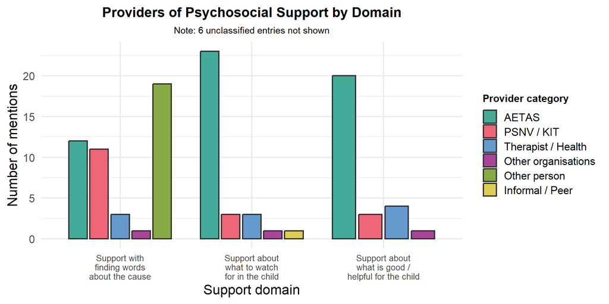

## Psychological Support

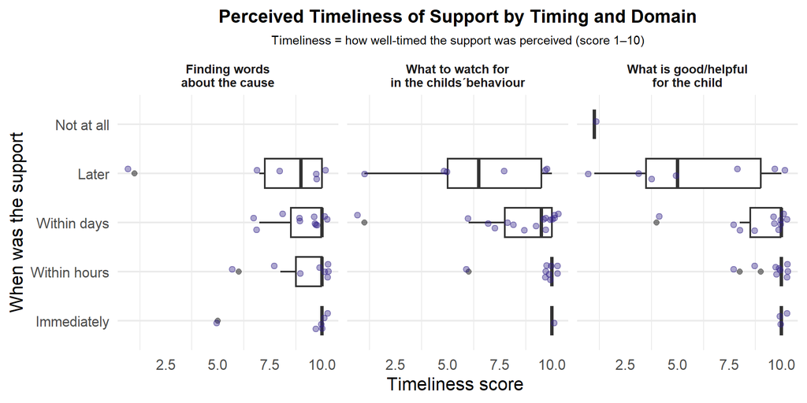

## Psychological Support

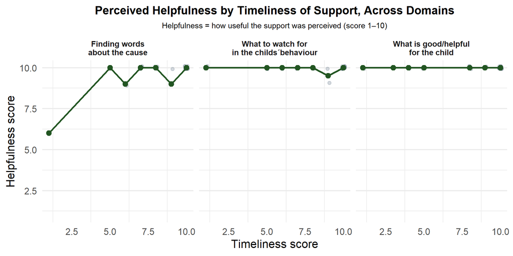

## Psychological Support

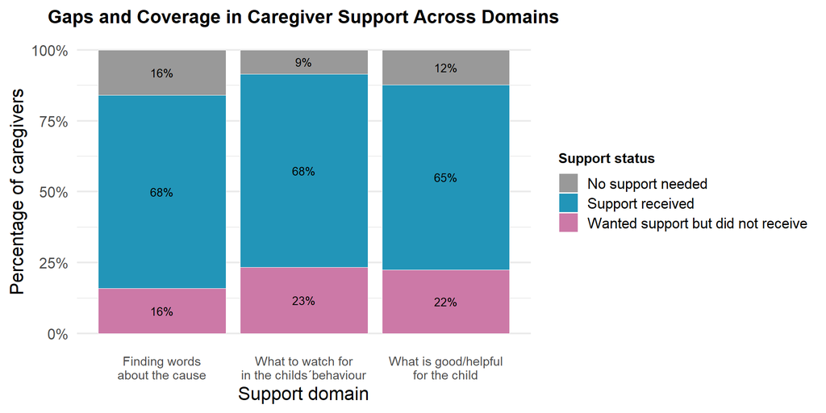

## Psychological Support

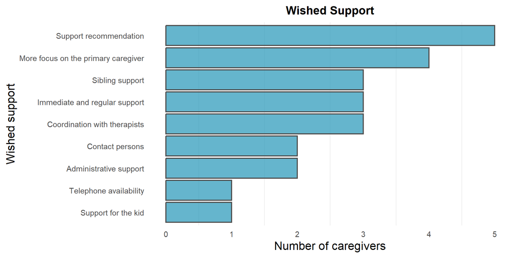

# Data Analysis

- Stress & Experience of Caregivers

- Communication with Children

- Psychological Support

- Stress & Coping

## Stress & Coping

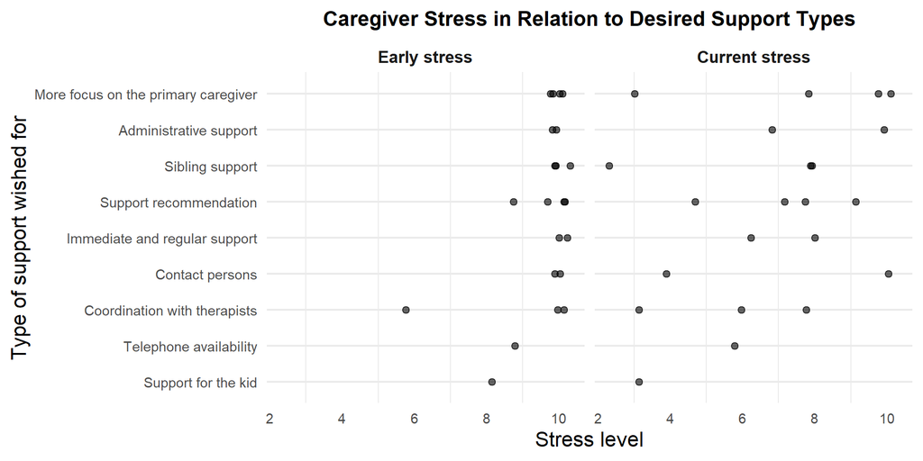

## Stress & Coping

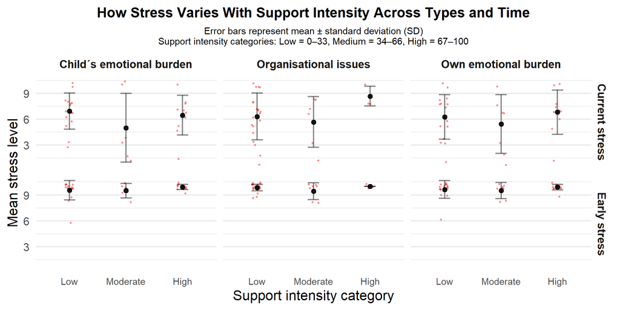

## Stress & Coping

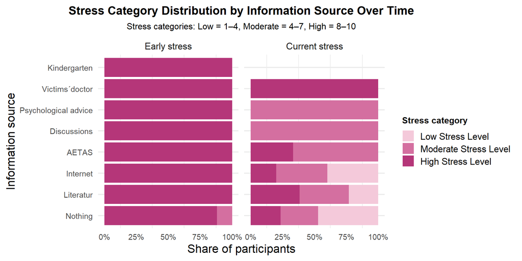

## Stress & Coping

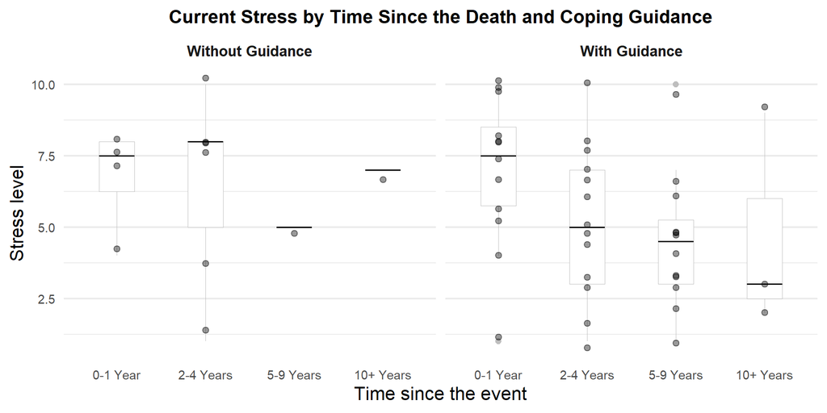

## Agenda

- Overview

- Data Analysis
  - Stress & Experience of Caregivers
  - Communication with Children
  - Psychological Support
  - Stress & Coping
- Conclusion & Discussion

# Conclusion

- Stress declines over time; support seekers show higher stress, likely due to greater initial burden.

# Conclusion

- Stress declines over time; support seekers show higher stress, likely due to greater initial burden.
- Communication with children varies by age, cause of death, and professional involvement.

# Conclusion

- Stress declines over time; support seekers show higher stress, likely due to greater initial burden.
- Communication with children varies by age, cause of death, and professional involvement.
- Caregivers rely on few providers and value early support, yet face unmet needs in guidance and coordination.

# Conclusion

- Stress declines over time; support seekers show higher stress, likely due to greater initial burden.
- Communication with children varies by age, cause of death, and professional involvement.
- Caregivers rely on few providers and value early support, yet face unmet needs in guidance and coordination.
- Information seeking is common; lack of coping support worsens stress, while moderate support helps most.

# Discussion

- *Self reporting bias:* Stress, communication strategies , and support perceptions may be influenced by memory and emotional state etc.

# Discussion

- *Self reporting bias:* Stress, communication strategies , and support perceptions may be influenced by memory and emotional state etc.
- *Incomplete responses:* Missing data limits comparability across some axes.

# Discussion

- *Self reporting bias:* Stress, communication strategies , and support perceptions may be influenced by memory and emotional state etc.
- *Incomplete responses:* Missing data limits comparability across some axes.
- *Heterogeneity of cases:* Families differ widely in context , number of children , cause of death and available support.

# Discussion

- *Self reporting bias:* Stress, communication strategies , and support perceptions may be influenced by memory and emotional state etc.
- *Incomplete responses:* Missing data limits comparability across some axes.
- *Heterogeneity of cases:* Families differ widely in context , number of children , cause of death and available support.
- *Timing effects:* Stress and support evaluations depend on when the events occured ; this cannot always be fully controlled

*Implications* - Structured , early guidance could significantly reduce caregivers´ burden. - Clear communication recommendations should be made more accessible. - Timely psychological support may improve coping for both caregivers and children